# Risk Factor Analysis

## Outcome Variable

**Outcome Variable:** stunted

## Predictor Variables

**Intervention Variable:** nchldlt5

**Adjustment Set:**

unadjusted

## Stratifying Variables

The analysis was stratified on these variable(s):

- agecat
- studyid

The following strata were considered:

- agecat: 12 months, studyid: ki1000108-IRC
- agecat: 12 months, studyid: ki1017093b-PROVIDE
- agecat: 12 months, studyid: ki1017093c-NIH-Crypto
- agecat: 12 months, studyid: ki1066203-TanzaniaChild2
- agecat: 12 months, studyid: ki1148112-LCNI-5
- agecat: 18 months, studyid: ki1000108-IRC
- agecat: 18 months, studyid: ki1017093b-PROVIDE
- agecat: 18 months, studyid: ki1017093c-NIH-Crypto
- agecat: 18 months, studyid: ki1066203-TanzaniaChild2
- agecat: 18 months, studyid: ki1148112-LCNI-5
- agecat: 24 months, studyid: ki1000108-IRC
- agecat: 24 months, studyid: ki1017093b-PROVIDE
- agecat: 24 months, studyid: ki1017093c-NIH-Crypto
- agecat: 24 months, studyid: ki1066203-TanzaniaChild2
- agecat: 24 months, studyid: ki1148112-LCNI-5
- agecat: 3 months, studyid: ki1000108-IRC
- agecat: 3 months, studyid: ki1017093b-PROVIDE
- agecat: 3 months, studyid: ki1017093c-NIH-Crypto
- agecat: 3 months, studyid: ki1066203-TanzaniaChild2
- agecat: 6 months, studyid: ki1000108-IRC
- agecat: 6 months, studyid: ki1017093b-PROVIDE
- agecat: 6 months, studyid: ki1017093c-NIH-Crypto
- agecat: 6 months, studyid: ki1066203-TanzaniaChild2
- agecat: 6 months, studyid: ki1148112-LCNI-5
- agecat: 9 months, studyid: ki1000108-IRC
- agecat: 9 months, studyid: ki1017093b-PROVIDE
- agecat: 9 months, studyid: ki1017093c-NIH-Crypto
- agecat: 9 months, studyid: ki1066203-TanzaniaChild2
- agecat: 9 months, studyid: ki1148112-LCNI-5
- agecat: Birth, studyid: ki1000108-IRC
- agecat: Birth, studyid: ki1017093c-NIH-Crypto

### Dropped Strata

Some strata were dropped due to rare outcomes:

- agecat: 12 months, studyid: ki1017093b-PROVIDE
- agecat: 12 months, studyid: ki1017093c-NIH-Crypto
- agecat: 12 months, studyid: ki1066203-TanzaniaChild2
- agecat: 12 months, studyid: ki1148112-LCNI-5
- agecat: 18 months, studyid: ki1017093b-PROVIDE
- agecat: 18 months, studyid: ki1017093c-NIH-Crypto
- agecat: 18 months, studyid: ki1066203-TanzaniaChild2
- agecat: 18 months, studyid: ki1148112-LCNI-5
- agecat: 24 months, studyid: ki1017093b-PROVIDE
- agecat: 24 months, studyid: ki1017093c-NIH-Crypto
- agecat: 24 months, studyid: ki1066203-TanzaniaChild2
- agecat: 24 months, studyid: ki1148112-LCNI-5
- agecat: 3 months, studyid: ki1017093b-PROVIDE
- agecat: 3 months, studyid: ki1017093c-NIH-Crypto
- agecat: 3 months, studyid: ki1066203-TanzaniaChild2
- agecat: 6 months, studyid: ki1017093b-PROVIDE
- agecat: 6 months, studyid: ki1017093c-NIH-Crypto
- agecat: 6 months, studyid: ki1066203-TanzaniaChild2
- agecat: 6 months, studyid: ki1148112-LCNI-5
- agecat: 9 months, studyid: ki1017093b-PROVIDE
- agecat: 9 months, studyid: ki1017093c-NIH-Crypto
- agecat: 9 months, studyid: ki1066203-TanzaniaChild2
- agecat: 9 months, studyid: ki1148112-LCNI-5
- agecat: Birth, studyid: ki1017093c-NIH-Crypto

## Methods Detail

We’re interested in the causal parameters $E[Y_a]$ for all values of $a \in \mathcal{A}$. These parameters represent the mean outcome if, possibly contrary to fact, we intervened to set all units to have $A=a$. Under the randomization and positivity assumptions, these are identified by the statistical parameters $\psi_a=E_W[E_{Y|A,W}(Y|A=a,W)]$. In addition, we’re interested in the mean of $Y$, $E[Y]$ under no intervention (the observed mean). We will estimate these parameters by using SuperLearner to fit the relevant likelihood factors – $E_{Y|A,W}(Y|A=a,W)$ and $p(A=a|W)$, and then updating our likelihood fit using a joint TMLE.

For unadjusted analyses ($W=\{\}$), initial likelihoods were estimated using Lrnr_glm to estimate the simple $E(Y|A)$ and Lrnr_mean to estimate $p(A)$. For adjusted analyses, a small library containing Lrnr_glmnet, Lrnr_xgboost, and Lrnr_mean was used.

Having estimated these parameters, we will then use the delta method to estimate relative risks and attributable risks relative to a prespecified baseline level of $A$.

# Results Detail

## Results Plots

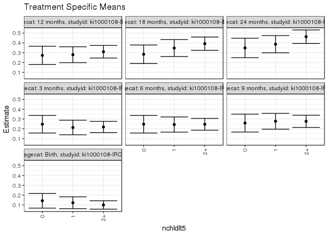

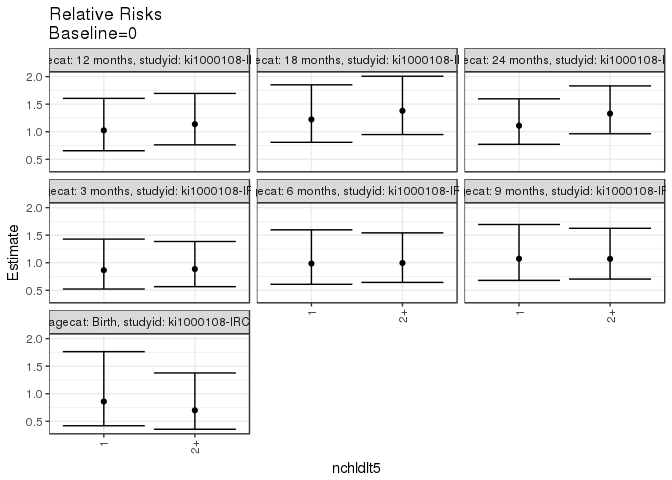

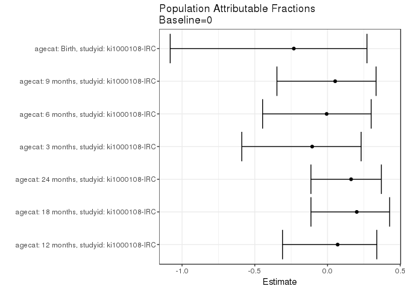

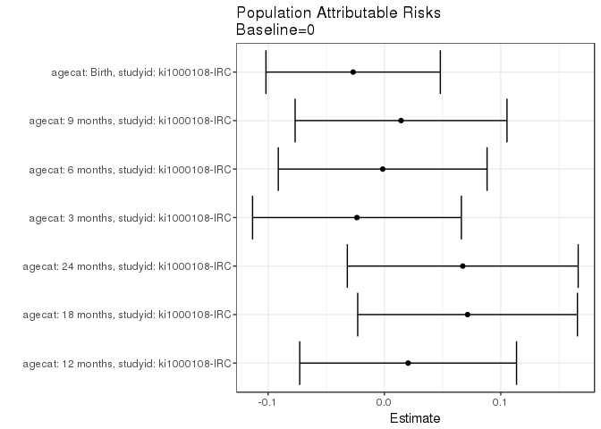

## Data Summary

| agecat | studyid | A | n | nA | nAY0 | nAY1 |
| --- | --- | --- | --- | --- | --- | --- |
| 12 months | ki1000108-IRC | 0 | 406 | 88 | 64 | 24 |
| 12 months | ki1000108-IRC | 1 | 406 | 118 | 85 | 33 |
| 12 months | ki1000108-IRC | 2+ | 406 | 200 | 138 | 62 |
| 12 months | ki1017093b-PROVIDE | 0 | 153 | 107 | 75 | 32 |
| 12 months | ki1017093b-PROVIDE | 1 | 153 | 44 | 32 | 12 |
| 12 months | ki1017093b-PROVIDE | 2+ | 153 | 2 | 2 | 0 |
| 12 months | ki1017093c-NIH-Crypto | 0 | 706 | 500 | 384 | 116 |
| 12 months | ki1017093c-NIH-Crypto | 1 | 706 | 202 | 147 | 55 |
| 12 months | ki1017093c-NIH-Crypto | 2+ | 706 | 4 | 4 | 0 |
| 12 months | ki1066203-TanzaniaChild2 | 0 | 356 | 245 | 204 | 41 |
| 12 months | ki1066203-TanzaniaChild2 | 1 | 356 | 100 | 91 | 9 |
| 12 months | ki1066203-TanzaniaChild2 | 2+ | 356 | 11 | 9 | 2 |
| 12 months | ki1148112-LCNI-5 | 0 | 306 | 2 | 1 | 1 |
| 12 months | ki1148112-LCNI-5 | 1 | 306 | 141 | 92 | 49 |
| 12 months | ki1148112-LCNI-5 | 2+ | 306 | 163 | 88 | 75 |
| 18 months | ki1000108-IRC | 0 | 405 | 88 | 63 | 25 |
| 18 months | ki1000108-IRC | 1 | 405 | 118 | 77 | 41 |
| 18 months | ki1000108-IRC | 2+ | 405 | 199 | 121 | 78 |
| 18 months | ki1017093b-PROVIDE | 0 | 141 | 99 | 64 | 35 |
| 18 months | ki1017093b-PROVIDE | 1 | 141 | 40 | 23 | 17 |
| 18 months | ki1017093b-PROVIDE | 2+ | 141 | 2 | 2 | 0 |
| 18 months | ki1017093c-NIH-Crypto | 0 | 634 | 447 | 318 | 129 |
| 18 months | ki1017093c-NIH-Crypto | 1 | 634 | 183 | 123 | 60 |
| 18 months | ki1017093c-NIH-Crypto | 2+ | 634 | 4 | 2 | 2 |
| 18 months | ki1066203-TanzaniaChild2 | 0 | 257 | 178 | 131 | 47 |
| 18 months | ki1066203-TanzaniaChild2 | 1 | 257 | 70 | 53 | 17 |
| 18 months | ki1066203-TanzaniaChild2 | 2+ | 257 | 9 | 5 | 4 |
| 18 months | ki1148112-LCNI-5 | 0 | 353 | 3 | 1 | 2 |
| 18 months | ki1148112-LCNI-5 | 1 | 353 | 167 | 94 | 73 |
| 18 months | ki1148112-LCNI-5 | 2+ | 353 | 183 | 84 | 99 |

[output cut: 75 more lines]

## Results Table

### Parameter: TSM

| agecat | studyid | intervention_level | baseline_level | estimate | ci_lower | ci_upper |
| --- | --- | --- | --- | --- | --- | --- |
| 12 months | ki1000108-IRC | 0 | NA | 0.2727273 | 0.1795618 | 0.3658928 |
| 12 months | ki1000108-IRC | 1 | NA | 0.2796610 | 0.1985785 | 0.3607435 |
| 12 months | ki1000108-IRC | 2+ | NA | 0.3100000 | 0.2458238 | 0.3741762 |
| 18 months | ki1000108-IRC | 0 | NA | 0.2840909 | 0.1897498 | 0.3784321 |
| 18 months | ki1000108-IRC | 1 | NA | 0.3474576 | 0.2614377 | 0.4334776 |
| 18 months | ki1000108-IRC | 2+ | NA | 0.3919598 | 0.3240480 | 0.4598716 |
| 24 months | ki1000108-IRC | 0 | NA | 0.3483146 | 0.2492110 | 0.4474182 |
| 24 months | ki1000108-IRC | 1 | NA | 0.3865546 | 0.2989555 | 0.4741537 |
| 24 months | ki1000108-IRC | 2+ | NA | 0.4626866 | 0.3936723 | 0.5317008 |
| 3 months | ki1000108-IRC | 0 | NA | 0.2471910 | 0.1574593 | 0.3369227 |
| 3 months | ki1000108-IRC | 1 | NA | 0.2136752 | 0.1393104 | 0.2880400 |
| 3 months | ki1000108-IRC | 2+ | NA | 0.2189055 | 0.1616701 | 0.2761408 |
| 6 months | ki1000108-IRC | 0 | NA | 0.2471910 | 0.1574593 | 0.3369227 |
| 6 months | ki1000108-IRC | 1 | NA | 0.2436975 | 0.1664682 | 0.3209268 |
| 6 months | ki1000108-IRC | 2+ | NA | 0.2462312 | 0.1863009 | 0.3061614 |
| 9 months | ki1000108-IRC | 0 | NA | 0.2584270 | 0.1673658 | 0.3494881 |
| 9 months | ki1000108-IRC | 1 | NA | 0.2773109 | 0.1967790 | 0.3578428 |
| 9 months | ki1000108-IRC | 2+ | NA | 0.2763819 | 0.2141712 | 0.3385926 |
| Birth | ki1000108-IRC | 0 | NA | 0.1428571 | 0.0679288 | 0.2177855 |
| Birth | ki1000108-IRC | 1 | NA | 0.1228070 | 0.0624795 | 0.1831345 |
| Birth | ki1000108-IRC | 2+ | NA | 0.1000000 | 0.0572877 | 0.1427123 |

### Parameter: E(Y)

| agecat | studyid | intervention_level | baseline_level | estimate | ci_lower | ci_upper |
| --- | --- | --- | --- | --- | --- | --- |
| 12 months | ki1000108-IRC | NA | NA | 0.2931034 | 0.2914646 | 0.2947423 |
| 18 months | ki1000108-IRC | NA | NA | 0.3555556 | 0.3514415 | 0.3596696 |
| 24 months | ki1000108-IRC | NA | NA | 0.4156479 | 0.4109740 | 0.4203219 |
| 3 months | ki1000108-IRC | NA | NA | 0.2235872 | 0.2223534 | 0.2248211 |
| 6 months | ki1000108-IRC | NA | NA | 0.2457002 | 0.2455699 | 0.2458306 |
| 9 months | ki1000108-IRC | NA | NA | 0.2727273 | 0.2719904 | 0.2734642 |
| Birth | ki1000108-IRC | NA | NA | 0.1159794 | 0.1142678 | 0.1176910 |

### Parameter: RR

| agecat | studyid | intervention_level | baseline_level | estimate | ci_lower | ci_upper |
| --- | --- | --- | --- | --- | --- | --- |
| 12 months | ki1000108-IRC | 1 | 0 | 1.0254237 | 0.6551104 | 1.605063 |
| 12 months | ki1000108-IRC | 2+ | 0 | 1.1366667 | 0.7623570 | 1.694759 |
| 18 months | ki1000108-IRC | 1 | 0 | 1.2230508 | 0.8082695 | 1.850686 |
| 18 months | ki1000108-IRC | 2+ | 0 | 1.3796985 | 0.9486664 | 2.006572 |
| 24 months | ki1000108-IRC | 1 | 0 | 1.1097858 | 0.7713798 | 1.596651 |
| 24 months | ki1000108-IRC | 2+ | 0 | 1.3283582 | 0.9633801 | 1.831609 |
| 3 months | ki1000108-IRC | 1 | 0 | 0.8644134 | 0.5227814 | 1.429298 |
| 3 months | ki1000108-IRC | 2+ | 0 | 0.8855721 | 0.5661557 | 1.385198 |
| 6 months | ki1000108-IRC | 1 | 0 | 0.9858671 | 0.6088959 | 1.596223 |
| 6 months | ki1000108-IRC | 2+ | 0 | 0.9961169 | 0.6434315 | 1.542121 |
| 9 months | ki1000108-IRC | 1 | 0 | 1.0730727 | 0.6797108 | 1.694081 |
| 9 months | ki1000108-IRC | 2+ | 0 | 1.0694778 | 0.7040163 | 1.624654 |
| Birth | ki1000108-IRC | 1 | 0 | 0.8596491 | 0.4190143 | 1.763655 |
| Birth | ki1000108-IRC | 2+ | 0 | 0.7000000 | 0.3559067 | 1.376766 |

### Parameter: PAR

| agecat | studyid | intervention_level | baseline_level | estimate | ci_lower | ci_upper |
| --- | --- | --- | --- | --- | --- | --- |
| 12 months | ki1000108-IRC | 0 | NA | 0.0203762 | -0.0728038 | 0.1135561 |
| 18 months | ki1000108-IRC | 0 | NA | 0.0714646 | -0.0229662 | 0.1658955 |
| 24 months | ki1000108-IRC | 0 | NA | 0.0673333 | -0.0318805 | 0.1665471 |
| 3 months | ki1000108-IRC | 0 | NA | -0.0236038 | -0.1133440 | 0.0661364 |
| 6 months | ki1000108-IRC | 0 | NA | -0.0014908 | -0.0912226 | 0.0882411 |
| 9 months | ki1000108-IRC | 0 | NA | 0.0143003 | -0.0767638 | 0.1053644 |
| Birth | ki1000108-IRC | 0 | NA | -0.0268778 | -0.1018257 | 0.0480702 |

### Parameter: PAF

| agecat | studyid | intervention_level | baseline_level | estimate | ci_lower | ci_upper |
| --- | --- | --- | --- | --- | --- | --- |
| 12 months | ki1000108-IRC | 0 | NA | 0.0695187 | -0.3094397 | 0.3388047 |
| 18 months | ki1000108-IRC | 0 | NA | 0.2009943 | -0.1139310 | 0.4268854 |
| 24 months | ki1000108-IRC | 0 | NA | 0.1619960 | -0.1140622 | 0.3696486 |
| 3 months | ki1000108-IRC | 0 | NA | -0.1055686 | -0.5894806 | 0.2310181 |
| 6 months | ki1000108-IRC | 0 | NA | -0.0060674 | -0.4463673 | 0.3001974 |
| 9 months | ki1000108-IRC | 0 | NA | 0.0524345 | -0.3478602 | 0.3338475 |
| Birth | ki1000108-IRC | 0 | NA | -0.2317460 | -1.0816046 | 0.2711400 |